# Assignment 3

# Machine Learning Assignment 3

Hands on with Regression

## Problem 1

```r
options(scipen=999)
# Libraries
library(caret)
library(leaps)
library(rpart)
library(rpart.plot)
```

### Question 1

- 777 Observations
- Categoric/Numeric
  - Categoric: 2
    - X (name of college) is unique per observation and is more of a key
  - Numeric: 17
- No nulls, 2 values in perc.alumni are 0 but that is a reasonable value in data

```r
college <- read.csv("data/College.csv", stringsAsFactors=TRUE)
# Summary of data
summary(college)
```

```
                            X       Private        Apps           Accept          Enroll       Top10perc       Top25perc      F.Undergrad     P.Undergrad
 Abilene Christian University:  1   No :212   Min.   :   81   Min.   :   72   Min.   :  35   Min.   : 1.00   Min.   :  9.0   Min.   :  139   Min.   :    1.0
 Adelphi University          :  1   Yes:565   1st Qu.:  776   1st Qu.:  604   1st Qu.: 242   1st Qu.:15.00   1st Qu.: 41.0   1st Qu.:  992   1st Qu.:   95.0
 Adrian College              :  1             Median : 1558   Median : 1110   Median : 434   Median :23.00   Median : 54.0   Median : 1707   Median :  353.0
 Agnes Scott College         :  1             Mean   : 3002   Mean   : 2019   Mean   : 780   Mean   :27.56   Mean   : 55.8   Mean   : 3700   Mean   :  855.3
 Alaska Pacific University   :  1             3rd Qu.: 3624   3rd Qu.: 2424   3rd Qu.: 902   3rd Qu.:35.00   3rd Qu.: 69.0   3rd Qu.: 4005   3rd Qu.:  967.0
 Albertson College           :  1             Max.   :48094   Max.   :26330   Max.   :6392   Max.   :96.00   Max.   :100.0   Max.   :31643   Max.   :21836.0
 (Other)                     :771
    Outstate       Room.Board       Books           Personal         PhD            Terminal       S.F.Ratio      perc.alumni        Expend        Grad.Rate
 Min.   : 2340   Min.   :1780   Min.   :  96.0   Min.   : 250   Min.   :  8.00   Min.   : 24.0   Min.   : 2.50   Min.   : 0.00   Min.   : 3186   Min.   : 10.00
 1st Qu.: 7320   1st Qu.:3597   1st Qu.: 470.0   1st Qu.: 850   1st Qu.: 62.00   1st Qu.: 71.0   1st Qu.:11.50   1st Qu.:13.00   1st Qu.: 6751   1st Qu.: 53.00
 Median : 9990   Median :4200   Median : 500.0   Median :1200   Median : 75.00   Median : 82.0   Median :13.60   Median :21.00   Median : 8377   Median : 65.00
 Mean   :10441   Mean   :4358   Mean   : 549.4   Mean   :1341   Mean   : 72.66   Mean   : 79.7   Mean   :14.09   Mean   :22.74   Mean   : 9660   Mean   : 65.46
 3rd Qu.:12925   3rd Qu.:5050   3rd Qu.: 600.0   3rd Qu.:1700   3rd Qu.: 85.00   3rd Qu.: 92.0   3rd Qu.:16.50   3rd Qu.:31.00   3rd Qu.:10830   3rd Qu.: 78.00
 Max.   :21700   Max.   :8124   Max.   :2340.0   Max.   :6800   Max.   :103.00   Max.   :100.0   Max.   :39.80   Max.   :64.00   Max.   :56233   Max.   :118.00
```

```r
# View Null and NA
colSums(college == 0 | is.na(college))
```

```
          X     Private        Apps      Accept      Enroll   Top10perc   Top25perc F.Undergrad P.Undergrad    Outstate  Room.Board       Books    Personal
          0           0           0           0           0           0           0           0           0           0           0           0           0
        PhD    Terminal   S.F.Ratio perc.alumni      Expend   Grad.Rate
          0           0           0           2           0           0
```

### Question 2

Remove name of college column

```r
college$X <- NULL
```

### Question 3

Variables Accept, Enroll, F.Undergrad for numeric and Private for categoric. P.Undergrad, PhD, Terminal, Top25perc, and Top10perc could be used as a last effort but the correlation is much lower at .3-.4

```r
# Numeric
## Series of functions to pivot large correlation table and display
numCols <- sapply(college, is.numeric)
college_cor <- cor(college[,numCols])
cor_df <- as.data.frame(as.table(college_cor))
cor_apps <- cor_df[cor_df$Var1=="Apps", ]
cor_apps[order(-cor_apps$Freq),]
```

|  | Var1 | Var2 | Freq |
| --- | --- | --- | --- |
| 1 | Apps | Apps | 1.00000000 |
| 18 | Apps | Accept | 0.94345057 |
| 35 | Apps | Enroll | 0.84682205 |
| 86 | Apps | F.Undergrad | 0.81449058 |
| 103 | Apps | P.Undergrad | 0.39826427 |
| 188 | Apps | PhD | 0.39069733 |
| 205 | Apps | Terminal | 0.36949147 |
| 69 | Apps | Top25perc | 0.35163990 |
| 52 | Apps | Top10perc | 0.33883368 |
| 256 | Apps | Expend | 0.25959198 |

[output cut: 7 more lines]

```r
# Categoric
t.test(college$Apps~college$Private, alternative="two.sided")
```

```
    Welch Two Sample t-test

data:  college$Apps by college$Private
t = 9.7985, df = 244.49, p-value < 0.00000000000000022
alternative hypothesis: true difference in means is not equal to 0
95 percent confidence interval:
 2997.758 4506.223
sample estimates:
 mean in group No mean in group Yes
         5729.920          1977.929
```

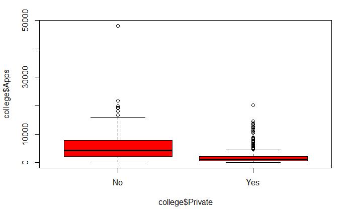

```r
plot(college$Apps~college$Private, col="red")
```

### Question 4

The plot for Apps is a right tail histogram. What this shows is a large proportion of colleges receive a small number of applications (more than 600 colleges receive less than 10000 applications). Outliers are pulling the histogram to the right and causing larger buckets as well, further skewing plot.

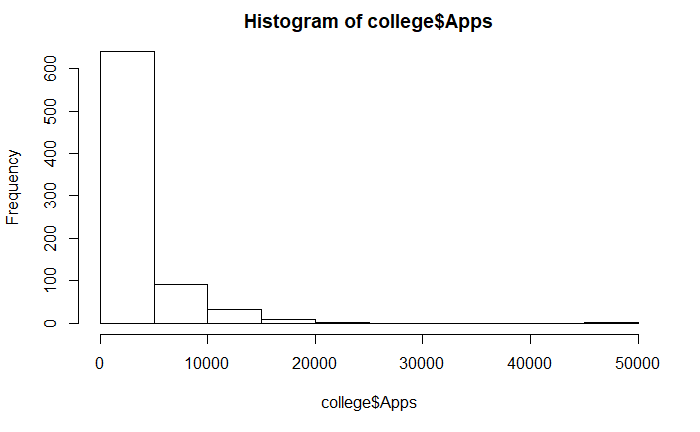

```r
hist(college$Apps)
```

### Question 5

Distribution is now corrected and more symmetric after replacing with logarithm of Apps.

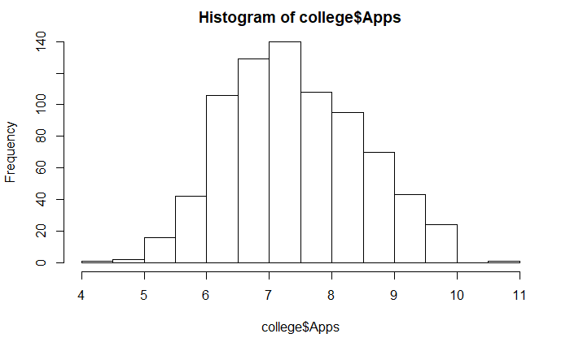

```r
college$Apps <- log(college$Apps)
hist(college$Apps)
```

### Question 6

Replaced Top10perc with Elite column

```r
college$Elite <- as.factor(ifelse(college$Top10perc >= 50, "Yes", "No"))
college$Top10perc <- NULL
```

### Question 7

There is a statistically significant difference as shown by the p-value<alpha and side by side box plot. “Yes” has a statistically different mean that is higher than “No”. Thus, it may benefit using the new Elite feature that was based on the previously not recommended Top10perc feature.

```r
# Categoric
t.test(college$Apps~college$Elite, alternative="two.sided")
```

```
    Welch Two Sample t-test

data:  college$Apps by college$Elite
t = -8.4365, df = 106.26, p-value = 0.0000000000001778
alternative hypothesis: true difference in means is not equal to 0
95 percent confidence interval:
 -1.176238 -0.728607
sample estimates:
 mean in group No mean in group Yes
         7.324853          8.277275
```

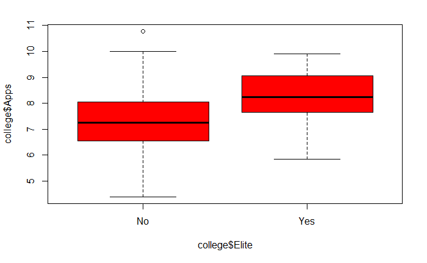

```r
plot(college$Apps~college$Elite, col="red")
```

### Question 8

Data split on initial run according to 80% or apprxoimately 621 observations.

```r
smp_size <- floor(.80 * nrow(college))
smp_size_plus <- smp_size+1
pop_size <- as.numeric(nrow(college))
college_train <- college[1:smp_size,]
college_test <- college[smp_size_plus:pop_size,]
```

### Question 9

```r
set.seed(123)
```

### Question 10

Linear Regression with 10 fold cross validation with all features. The model shows PrivateYes, Accept, Enroll, S.F.Ratio, Expend, and Grad.Rate as all statistically different from 0. This means these variables have a statistically significant effect on the outcome variable Apps.

Mistake: train() function was used on college instead of college_train

```r
set.seed(123)
attach(college)
train.control <- trainControl(method="cv", number=10)
college_kf <- train(Apps~.,
                      data=college,
                      method="lm",
                      trControl=train.control)
print(college_kf)
```

```
Linear Regression

777 samples
 17 predictor

No pre-processing
Resampling: Cross-Validated (10 fold)
Summary of sample sizes: 700, 700, 701, 698, 700, 699, ...
Resampling results:

  RMSE       Rsquared   MAE
  0.5301908  0.7698371  0.3997668

Tuning parameter 'intercept' was held constant at a value of TRUE
```

```r
summary(college_kf)
```

```
Call:
lm(formula = .outcome ~ ., data = dat)

Residuals:
     Min       1Q   Median       3Q      Max
-2.53509 -0.28293  0.06619  0.32455  1.60151

Coefficients:
                Estimate   Std. Error t value             Pr(>|t|)
(Intercept)  4.530590882  0.197584840  22.930 < 0.0000000000000002 ***
PrivateYes  -0.584850786  0.068586187  -8.527 < 0.0000000000000002 ***
Accept       0.000168406  0.000019926   8.452 < 0.0000000000000002 ***
Enroll       0.000379716  0.000091467   4.151       0.000036788523 ***
Top25perc    0.004433600  0.001457516   3.042              0.00243 **
F.Undergrad -0.000040815  0.000016176  -2.523              0.01183 *
P.Undergrad  0.000036368  0.000015851   2.294              0.02204 *
Outstate     0.000030927  0.000009398   3.291              0.00105 **
Room.Board   0.000059407  0.000023851   2.491              0.01296 *
Books        0.000310677  0.000117622   2.641              0.00843 **
Personal     0.000046997  0.000031141   1.509              0.13167
PhD          0.005777735  0.002275018   2.540              0.01129 *
Terminal     0.001349676  0.002498401   0.540              0.58921
S.F.Ratio    0.040811202  0.006426354   6.351       0.000000000369 ***
perc.alumni -0.005389642  0.002024787  -2.662              0.00794 **
Expend       0.000024241  0.000005931   4.087       0.000048339640 ***
Grad.Rate    0.007891464  0.001453742   5.428       0.000000076580 ***
EliteYes     0.108712180  0.081922878   1.327              0.18491
---
Signif. codes:  0 ‘***’ 0.001 ‘**’ 0.01 ‘*’ 0.05 ‘.’ 0.1 ‘ ’ 1

Residual standard error: 0.5141 on 759 degrees of freedom
Multiple R-squared:  0.7757,    Adjusted R-squared:  0.7707
F-statistic: 154.4 on 17 and 759 DF,  p-value: < 0.00000000000000022
```

### Question 11

```r
set.seed(123)
college_pred <- predict(college_kf, college_test)
RMSE <- sqrt(mean(abs(college_test$Apps-college_pred)^2))
RMSE
```

```
[1] 0.4650652
```

### Question 12

```r
set.seed(123)
```

### Question 13

```r
set.seed(123)
train.control <- trainControl(method="cv", number=10)
college_stepBk <- train(Apps~.,
                        data=college_train,
                        method="leapBackward",
                        trControl=train.control,
                        tuneGrid=data.frame(nvmax=1:16))
#print(college_stepBk)
summary(college_stepBk$finalModel)
```

```
Subset selection object
17 Variables  (and intercept)
            Forced in Forced out
PrivateYes      FALSE      FALSE
Accept          FALSE      FALSE
Enroll          FALSE      FALSE
Top25perc       FALSE      FALSE
F.Undergrad     FALSE      FALSE
P.Undergrad     FALSE      FALSE
Outstate        FALSE      FALSE
Room.Board      FALSE      FALSE
Books           FALSE      FALSE
Personal        FALSE      FALSE
PhD             FALSE      FALSE
Terminal        FALSE      FALSE
S.F.Ratio       FALSE      FALSE
perc.alumni     FALSE      FALSE
Expend          FALSE      FALSE
Grad.Rate       FALSE      FALSE
EliteYes        FALSE      FALSE
1 subsets of each size up to 13
Selection Algorithm: backward
          PrivateYes Accept Enroll Top25perc F.Undergrad P.Undergrad Outstate Room.Board Books Personal PhD Terminal S.F.Ratio perc.alumni Expend Grad.Rate
1  ( 1 )  " "        "*"    " "    " "       " "         " "         " "      " "        " "   " "      " " " "      " "       " "         " "    " "
2  ( 1 )  " "        "*"    " "    "*"       " "         " "         " "      " "        " "   " "      " " " "      " "       " "         " "    " "
3  ( 1 )  "*"        "*"    " "    "*"       " "         " "         " "      " "        " "   " "      " " " "      " "       " "         " "    " "
4  ( 1 )  "*"        "*"    " "    "*"       " "         " "         " "      " "        " "   " "      " " " "      " "       " "         " "    "*"
5  ( 1 )  "*"        "*"    " "    "*"       " "         " "         " "      " "        " "   " "      " " " "      " "       " "         "*"    "*"
6  ( 1 )  "*"        "*"    " "    "*"       " "         " "         " "      " "        " "   " "      " " " "      "*"       " "         "*"    "*"
7  ( 1 )  "*"        "*"    " "    "*"       " "         " "         "*"      " "        " "   " "      " " " "      "*"       " "         "*"    "*"
8  ( 1 )  "*"        "*"    "*"    "*"       " "         " "         "*"      " "        " "   " "      " " " "      "*"       " "         "*"    "*"
9  ( 1 )  "*"        "*"    "*"    "*"       " "         " "         "*"      " "        " "   " "      "*" " "      "*"       " "         "*"    "*"
10  ( 1 ) "*"        "*"    "*"    "*"       " "         " "         "*"      " "        " "   " "      "*" " "      "*"       "*"         "*"    "*"
11  ( 1 ) "*"        "*"    "*"    "*"       " "         " "         "*"      " "        "*"   " "      "*" " "      "*"       "*"         "*"    "*"
12  ( 1 ) "*"        "*"    "*"    "*"       "*"         " "         "*"      " "        "*"   " "      "*" " "      "*"       "*"         "*"    "*"
13  ( 1 ) "*"        "*"    "*"    "*"       "*"         " "         "*"      "*"        "*"   " "      "*" " "      "*"       "*"         "*"    "*"
          EliteYes
1  ( 1 )  " "
2  ( 1 )  " "
3  ( 1 )  " "
4  ( 1 )  " "
5  ( 1 )  " "
6  ( 1 )  " "
7  ( 1 )  " "
8  ( 1 )  " "
9  ( 1 )  " "
10  ( 1 ) " "
11  ( 1 ) " "
12  ( 1 ) " "
13  ( 1 ) " "
```

### Question 14

RMSE was ~.489 for the Stepwise Backward function.

```r
college_stepBk_pred <- predict(college_stepBk, college_test)
RMSE_stepBk <- sqrt(mean(abs(college_test$Apps-college_stepBk_pred)^2))
RMSE_stepBk
```

```
[1] 0.4889923
```

### Question 15

```r
college_rpart <- rpart(Apps~., data=college_train)
college_rpart_pred <- predict(college_rpart, college_test)
RMSE_rpart <- sqrt(mean(abs(college_test$Apps-college_rpart_pred)^2))
RMSE_rpart
```

```
[1] 0.2985149
```

## Problem 2

### Question 1

Read in data, no observed nulls or zero values. Create train and test set.

```r
set.seed(123)
credit <- read.csv("data/credit.csv", stringsAsFactors=TRUE)
# Summary of data
summary(credit)
```

```
   checking_balance months_loan_duration   credit_history                 purpose        amount           savings_balance  employment_duration percent_of_income
 < 0 DM    :274     Min.   : 4.0         critical :293    business            : 97   Min.   :  250   < 100 DM     :603    < 1 year   :172      Min.   :1.000
 > 200 DM  : 63     1st Qu.:12.0         good     :530    car                 :337   1st Qu.: 1366   > 1000 DM    : 48    > 7 years  :253      1st Qu.:2.000
 1 - 200 DM:269     Median :18.0         perfect  : 40    car0                : 12   Median : 2320   100 - 500 DM :103    1 - 4 years:339      Median :3.000
 unknown   :394     Mean   :20.9         poor     : 88    education           : 59   Mean   : 3271   500 - 1000 DM: 63    4 - 7 years:174      Mean   :2.973
                    3rd Qu.:24.0         very good: 49    furniture/appliances:473   3rd Qu.: 3972   unknown      :183    unemployed : 62      3rd Qu.:4.000
                    Max.   :72.0                          renovations         : 22   Max.   :18424                                             Max.   :4.000
 years_at_residence      age        other_credit  housing    existing_loans_count         job        dependents    phone     default
 Min.   :1.000      Min.   :19.00   bank :139    other:108   Min.   :1.000        management:148   Min.   :1.000   no :596   no :700
 1st Qu.:2.000      1st Qu.:27.00   none :814    own  :713   1st Qu.:1.000        skilled   :630   1st Qu.:1.000   yes:404   yes:300
 Median :3.000      Median :33.00   store: 47    rent :179   Median :1.000        unemployed: 22   Median :1.000
 Mean   :2.845      Mean   :35.55                            Mean   :1.407        unskilled :200   Mean   :1.155
 3rd Qu.:4.000      3rd Qu.:42.00                            3rd Qu.:2.000                         3rd Qu.:1.000
 Max.   :4.000      Max.   :75.00                            Max.   :4.000                         Max.   :2.000
```

```r
# View Null and NA
colSums(credit == 0 | is.na(credit))
```

```
    checking_balance months_loan_duration       credit_history              purpose               amount      savings_balance  employment_duration
                   0                    0                    0                    0                    0                    0                    0
   percent_of_income   years_at_residence                  age         other_credit              housing existing_loans_count                  job
                   0                    0                    0                    0                    0                    0                    0
          dependents                phone              default
                   0                    0                    0
```

```r
# split train and test set
train_sample <- sample(1000, 900)
credit_train <- credit[train_sample,]
credit_test <- credit[-train_sample,]
```

### Question 2

Train using glm to predict default on test

```r
library(gmodels)
set.seed(123)
credit_glm <- glm(credit_train$default~., data=credit_train, family="binomial")
credit_pred <- predict(credit_glm, credit_test, type="response")
credit_pred_label <- as.factor(ifelse(credit_pred>.5, "yes", "no"))
```

### Question 3

```r
t=table(credit_test$default, credit_pred_label)
FPR=t[1,2]/(t[1,2]+t[1,1])
FPR
```

```
[1] 0.1343284
```

```r
CrossTable(credit_pred_label, credit_test$default,
           prop.chisq=FALSE,
           prop.t=FALSE,
           dnn=c("predicted","actual"))
```

```
   Cell Contents
|-------------------------|
|                       N |
|           N / Row Total |
|           N / Col Total |
|-------------------------|


Total Observations in Table:  100


             | actual
   predicted |        no |       yes | Row Total |
-------------|-----------|-----------|-----------|
          no |        58 |        19 |        77 |
             |     0.753 |     0.247 |     0.770 |
             |     0.866 |     0.576 |           |
-------------|-----------|-----------|-----------|
         yes |         9 |        14 |        23 |
             |     0.391 |     0.609 |     0.230 |
             |     0.134 |     0.424 |           |
-------------|-----------|-----------|-----------|
Column Total |        67 |        33 |       100 |
             |     0.670 |     0.330 |           |
-------------|-----------|-----------|-----------|
```

### Question 4

```r
set.seed(123)
library(DMwR)
# Over sample using SMOTE
credit_smote <- SMOTE(default~., data=credit_train, perc.over=100)
# Train new model
credit_smote_glm <- glm(credit_smote$default~., data=credit_smote, family="binomial")
credit_smote_pred <- predict(credit_smote_glm, credit_test, type="response")
credit_smote_pred_label <- as.factor(ifelse(credit_smote_pred>.5, "yes", "no"))
# View FPR/FNR and error rate
t=table(credit_test$default, credit_smote_pred_label)
FPR=t[1,2]/(t[1,2]+t[1,1])
FPR
```

```
[1] 0.2985075
```

```r
CrossTable(credit_smote_pred_label, credit_test$default,
           prop.chisq=FALSE,
           prop.t=FALSE,
           dnn=c("predicted","actual"))
```

```
   Cell Contents
|-------------------------|
|                       N |
|           N / Row Total |
|           N / Col Total |
|-------------------------|


Total Observations in Table:  100


             | actual
   predicted |        no |       yes | Row Total |
-------------|-----------|-----------|-----------|
          no |        47 |        12 |        59 |
             |     0.797 |     0.203 |     0.590 |
             |     0.701 |     0.364 |           |
-------------|-----------|-----------|-----------|
         yes |        20 |        21 |        41 |
             |     0.488 |     0.512 |     0.410 |
             |     0.299 |     0.636 |           |
-------------|-----------|-----------|-----------|
Column Total |        67 |        33 |       100 |
             |     0.670 |     0.330 |           |
-------------|-----------|-----------|-----------|
```